# CENTRO UNIVERSITÁRIO METODISTA IZABELA HENDRIX

12 de Abril de 2018

# Introdução

O Exame Nacional de Desempenho de Estudantes (Enade) avalia o rendimento dos concluintes dos cursos de graduação em relação aos conteúdos programáticos, habilidades e competências adquiridas em sua formação. O exame é obrigatório e a situação de regularidade do estudante no Exame deve constar em seu histórico escolar. A amostra analizada neste documento refere-se ao ano de 2014.

# Instalando os pacotes e acessando o banco de dados ENADE 2014

```r
enade14 <- read_csv2("https://raw.githubusercontent.com/neylsoncrepalde/introducao_ao_r/master/dados/enade_2014_amostra.csv")
```

```
Using ',' as decimal and '.' as grouping mark. Use read_delim() for more control.
`curl` package not installed, falling back to using `url()`
```

# Análises preliminares sobre o banco de dados ENADE 2014

1. Mostre com um comando e usando um gráfico a distribuição das idades dessa amostra de alunos que fizeram ENADE em 2014. Comente o resultado.

```
$breaks
 [1] 15 20 25 30 35 40 45 50 55 60 65 70 75

$counts
 [1]  268 3814 2231 1510  919  556  404  185   81   24    4    4

$density
 [1] 0.00536 0.07628 0.04462 0.03020 0.01838 0.01112 0.00808 0.00370 0.00162 0.00048 0.00008 0.00008

$mids
 [1] 17.5 22.5 27.5 32.5 37.5 42.5 47.5 52.5 57.5 62.5 67.5 72.5

$xname
[1] "enade14$nu_idade"

$equidist
[1] TRUE

attr(,"class")
[1] "histogram"
```

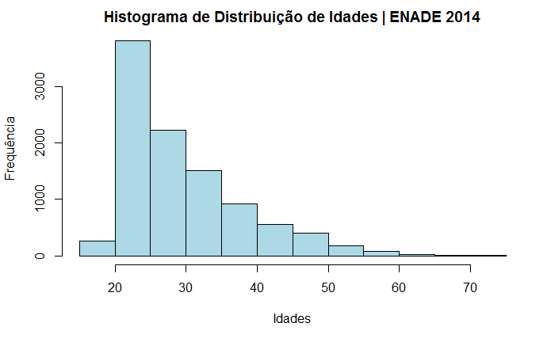

```r
print(hist(enade14$nu_idade, col = "light blue",
     main = "Histograma de Distribuição de Idades | ENADE 2014",
     xlab = "Idades",
     ylab = "Frequência"))
```

Comentário: O gráfico destaca uma grande concentração de alunos na faixa entre 20 e 25 anos que fizeram o exame. Outro índice expressivo é que 75% dos alunos que fizeram o ENADE possuem até 34 anos.

2. Monte uma tabela exibindo as porcentagens e os valores absolutos das proporções de alunos por COR/RAÇA. O descobrimos sobre isso?

```
na.omit(cor_raça)
         Frequência Percentual
Branco         4606    52.9791
Negro           893    10.2715
Pardo          2988    34.3685
Amarelo         129     1.4838
Indígena         78     0.8972
Total          8694   100.0000
```

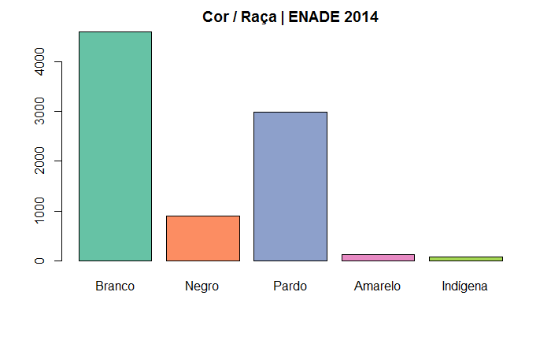

```r
print(freq(na.omit(cor_raça),
     col = cores,
     main = "Cor / Raça | ENADE 2014"))
```

Comentário: Este gráfico mostra uma disparidade na proporção de alunos que fizeram o exame em 2014. Mesmo o Brasil sendo um país com sua população negra em 53%, sengundo o Censo Demográfico em 2013, a concentração dos que se declararam Brancos no Exame Nacional é quase 5 vezes maior que os que se declararam Negros. Mesmo ao comparar com os alunos que se declararam Pardos ainda existe uma significativa diferença. Este dado revela que o acesso a educação no Brasil continua desproporcional.

3. Apresente a proporção de alunos casados e solteiros. Atenção, queremos apenas CASADOS e SOLTEIROS. Exclua de sua análise os alunos que tiverem outro tipo de estado civil.

```
casados_solteiros
            Frequência Percentual
Casado(a)         2486      31.18
Solteiro(a)       5487      68.82
Total             7973     100.00
```

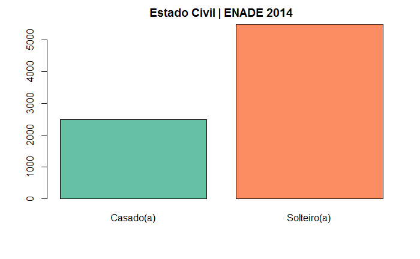

```r
print(freq(casados_solteiros, main = "Estado Civil | ENADE 2014",
           col = cores))
```

4. Apresente estatísticas descritivas sobre a nota geral dos alunos no Enade. Apresente também a informação em um gráfico. Qual é o gráfico mais adequado para a visualização desta variável? Por quê? Comente sobre a nota geral. Os alunos parecem ter, no geral, um bom desempenho ou um mal desempenho?

Resp.: O gráfico mais adequado será um boxplot, pois nos dá uma noção gráfica da distribuição e da varição do rendimento dos alunos.

```
$stats
     [,1]
[1,]    0
[2,]  292
[3,]  414
[4,]  528
[5,]  874
attr(,"class")

"integer"

$n
[1] 8276

$conf
         [,1]
[1,] 409.9012
[2,] 418.0988

$out
[1] 883 943 892 889 929

$group
[1] 1 1 1 1 1

$names
[1] ""
```

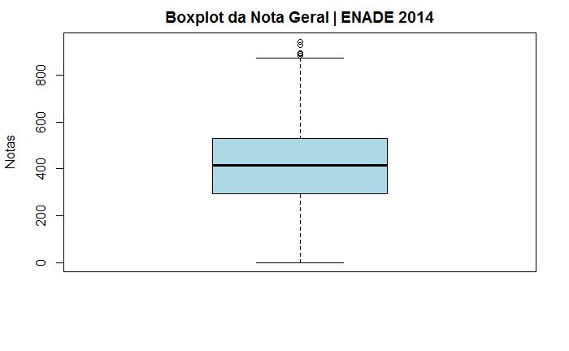

```r
print(boxplot(enade14$nt_ger,
        col = "light blue",
        main = "Boxplot da Nota Geral | ENADE 2014",
        ylab = "Notas"))
```

Comentário: É possível constatar que o rendimento geral dos alunos é muito baixo, dado que a média das notas ficou abaixo de 50%.

5. Crie uma variável binária chamada PUBLICA. Nessa variável, você deve marcar 1 se a universidade em que o aluno estudou foi pública e 0 se foi privada. ATENÇÃO: existe uma variável com a categoria administrativa da IES mas ela possui várias subclassificações. É preciso que você crie outra variável com as categorias corretas.

```
enade14$PUBLICA
              Frequência Percentual
Inst. Privada       6139      61.39
Inst. Pública       3861      38.61
Total              10000     100.00
```

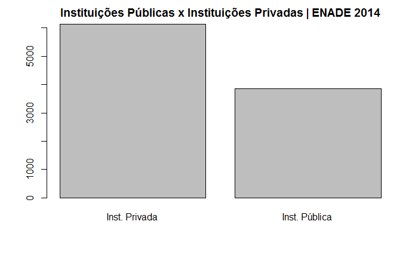

```r
print(freq(enade14$PUBLICA, main = "Instituições Públicas x Instituições Privadas | ENADE 2014"))
```

6. Mostre a distribuição da renda para os alunos do ENADE 2014. Mostre também a distribuição de renda apenas para os alunos das escolas públicas e das escolas privadas.

```
     [,1]
[1,]  0.7
[2,]  1.9
[3,]  3.1
[4,]  4.3
[5,]  5.5
[6,]  6.7
[7,]  7.9
```

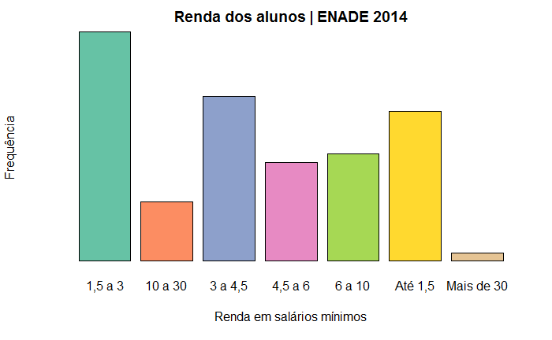

```r
print(barplot(table(enade14$renda_alunos),
        col = cores,
        main = "Renda dos alunos | ENADE 2014",
        xlab = "Renda em salários mínimos",
        ylab = "Frequência",
        axes = F))
```

7. Mostre agora a nota geral dos alunos das faculdades públicas e dos alunos das faculdades privadas. O que você acha desses dados?

```r
mean(nota_priv_geral, na.rm = T)
```

```
[1] 391.9547
```

Comentário: Pela amostra em 2014, os alunos de instituições públicas desempenharam um rendimento acadêmico superior aos alunos de instituições privadas.

# BONUS

1. Existe um teste estatístico para verificar se a média da nota geral desta amostra dos alunos que fizeram ENADE pode ser inferida para toda a população? Faça o teste e apresente os resultados. Qual é o intervalo de confiança do teste?

```r
t.test(enade14$nt_ger)
```

```
    One Sample t-test

data:  enade14$nt_ger
t = 197.26, df = 8275, p-value < 2.2e-16
alternative hypothesis: true mean is not equal to 0
95 percent confidence interval:
 395.6473 403.5898
sample estimates:
mean of x
 399.6185
```

2. Existe um teste estatístico para verificar se a diferença entre as notas dos alunos das universidades públicas e dos alunos das universidades privadas é estatisticamente significante? Faça o teste e apresente os resultados.

```r
t.test(nota_publica_geral, nota_priv_geral)
```

```
    Welch Two Sample t-test

data:  nota_publica_geral and nota_priv_geral
t = 4.6825, df = 6225.3, p-value = 2.895e-06
alternative hypothesis: true difference in means is not equal to 0
95 percent confidence interval:
 11.59509 28.29557
sample estimates:
mean of x mean of y
 411.9000  391.9547
```

# ==============================================================FIM